[Very statisticious](https://aosmith.rbind.io/)

# Simulate! Simulate! - Part 2: A linear mixed model

April 23, 2018 · [@aosmith16](https://twitter.com/aosmith16) · [View source](https://github.com/aosmith16/aosmith/blob/master/content/post/2018-04-23-simulate-simulate-part-2-a-linear-mixed-model.Rmd)

simulation, lmm, lme4

I feel like I learn something every time start simulating new data to update an assignment or exploring a question from a client via simulation. I’ve seen instances where residual autocorrelation isn’t detectable when I *know* it exists (because I simulated it) or I have skewed residuals and/or unequal variances when I simulated residuals from a normal distribution with a single variance. Such results are often due to small sample sizes, which even in this era of big data still isn’t so unusual in ecology. I’ve found exploring the effect of sample size on statistical results to be quite eye-opening 👁.

In [my first simulation post](https://aosmith.rbind.io/2018/01/09/simulate-simulate-part1/) I showed how to simulate data for a basic linear model. Today I’ll be talking about how to simulate data for a linear mixed model. So I’m still working with normally distributed residuals but will add an additional level of variation.

## Table of Contents

- Simulate, simulate, dance to the music
- The statistical model
- A single simulation for the two-level model
- Make a function for the simulation
- Repeat the simulation many times
- Extract results from the linear mixed model
- Explore the effect of sample size on variance estimation
- An actual mixed model (with fixed effects this time)
- Just the code, please

# Simulate, simulate, dance to the music

I learned the basics of linear mixed models in a class where we learned how to analyze data from “classically designed” experiments. We spent a lot of time writing down the various statistical models in mathematical notation and then fitting said models in SAS. I felt like I understood the basics of mixed models when the class was over (and swore I was done with all the $ii$ and $jj$ mathematical notation once and for all 😆).

It wasn’t until I started working with clients and teaching labs on mixed models in R that I learned how to do simulations to understand how well such models worked under various scenarios. These simulations took me to a whole new level of understanding of these models and the meaning of all that pesky mathematical notation.

# The statistical model

**Danger, equations below!**

You can opt to jump to the next section if you don’t find equations useful.

If you don’t have a good understanding of the statistical model (or even if you do), writing it out in mathematical notation can actually be pretty useful. I’ll write a relatively simple model with random effects below. (Note that I only have an overall mean in this model; I’ll do a short example at the end of the post to show how one can simulate additional fixed effects.)

The study design that is the basis of my model has two different sizes of study units. I’m using a classic forestry example, where stands of trees are somehow chosen for sampling and then multiple plots within each stand are measured. This is a design with two levels, stands and plots; we could add a third level if individual trees were measured in each plot.

Everything today will be perfectly balanced, so the same number of plots will be sampled in each stand.

I’m using (somewhat sloppy) “regression” style notation instead of experimental design notation, where the $tt$ indexes the observations.

# A single simulation for the two-level model

Let’s jump in and start simulating, as I find the statistical model becomes clearer once we have a simulated dataset to look at.

Here is what the dataset I will create will look like. I have a variable for stands (`stand`), plots (`plot`), and the response variable (`resp`).

```bash
#    stand plot      resp
# 1      A    a 10.484415
# 2      A    b  9.946876
# 3      A    c 11.016389
# 4      A    d 11.977799
# 5      B    e 10.322382
# 6      B    f 11.596422
# 7      B    g  9.861173
# 8      B    h  9.003203
# 9      C    i 13.850646
# 10     C    j 12.914153
# 11     C    k 10.529352
# 12     C    l 12.768342
# 13     D    m  7.584302
# 14     D    n  6.568810
# 15     D    o  8.239229
# 16     D    p  5.463744
# 17     E    q 11.981485
# 18     E    r 12.112977
# 19     E    s 13.766137
# 20     E    t 11.429760
```

I’ll start by setting the seed so these results can be exactly reproduced.

```r
set.seed(16)
```

I need to define the “truth” in the simulation by setting all the parameters in the statistical model to a value of my choosing. Here’s what I’ll do today.

- The true mean ($μμ$) will be 10
- The stand-level variance ($σ2sσs2$) will be set at 4, so the standard deviation ($σsσs$) is 2.
- The observation-level random effect variance ($σ2σ2$) will be set at 1, so the standard deviation ($σσ$) is 1.

I’ll define the number of groups and number of replicates per group while I’m at it. I’ll use 5 stands and 4 plots per stand. The total number of plots (and so observations) is the number of stands times the number of plots per stand: `5*4 = 20`.

```r
nstand = 5
nplot = 4
mu = 10
sds = 2
sd = 1
```

I need to create a `stand` variable, containing unique names for the five sampled stands. I use capital letters for this. Each stand name will be repeated four times, because each one was measured four times (i.e., there are four plots in each stand).

```r
( stand = rep(LETTERS[1:nstand], each = nplot) )
```

```bash
#  [1] "A" "A" "A" "A" "B" "B" "B" "B" "C" "C" "C" "C" "D" "D" "D" "D" "E" "E" "E"
# [20] "E"
```

I can make a `plot` variable, as well, although it’s not needed for modeling since we have a single value per plot. It is fairly common to give plots the same name in each stand (i.e., plots are named 1-4 in each stand), but I’m a big believer in giving plots unique names. I’ll name plots uniquely using lowercase letters. There are a total of 20 plots.

```r
( plot = letters[1:(nstand*nplot)] )
```

```bash
#  [1] "a" "b" "c" "d" "e" "f" "g" "h" "i" "j" "k" "l" "m" "n" "o" "p" "q" "r" "s"
# [20] "t"
```

Now I will simulate the stand-level random effects. I defined these as $bs∼N(0,σ2s)bs∼N(0,σs2)$, so will randomly draw from a normal distribution with a mean of 0 and standard deviation of 2 (remember that `rnorm()` in R uses standard deviation, not variance). I have five stands, so I draw five values.

```r
( standeff = rnorm(nstand, 0, sds) )
```

```css
# [1]  0.9528268 -0.2507600  2.1924324 -2.8884581  2.2956586
```

Every plot in a stand has the same “stand effect”, which I simulated with the five values above. This means that the stand itself is causing the measured response variable to be higher or lower than other stands across all plots in the stand. So the “stand effect” must be repeated for every plot in a stand.

The `stand` variable I made helps me know how to repeat the stand effect values. Based on that variable, every stand effect needs to be repeated four times in a row (once for each plot).

```r
( standeff = rep(standeff, each = nplot) )
```

```css
#  [1]  0.9528268  0.9528268  0.9528268  0.9528268 -0.2507600 -0.2507600
#  [7] -0.2507600 -0.2507600  2.1924324  2.1924324  2.1924324  2.1924324
# [13] -2.8884581 -2.8884581 -2.8884581 -2.8884581  2.2956586  2.2956586
# [19]  2.2956586  2.2956586
```

The observation-level random effect is simulated the same way as for a linear model. Every unique plot measurement has some effect on the response, and that effect is drawn from a normal distribution with a mean of 0 and a standard deviation of 1 ($ϵt∼N(0,σ2)ϵt∼N(0,σ2)$).

I make 20 draws from this distribution, one for every plot/observation.

```r
( ploteff = rnorm(nstand*nplot, 0, sd) )
```

```css
#  [1] -0.46841204 -1.00595059  0.06356268  1.02497260  0.57314202  1.84718210
#  [7]  0.11193337 -0.74603732  1.65821366  0.72172057 -1.66308050  0.57590953
# [13]  0.47276012 -0.54273166  1.12768707 -1.64779762 -0.31417395 -0.18268157
# [19]  1.47047849 -0.86589878
```

I’m going to put all of these variables in a dataset together. This helps me keep things organized for modeling but, more importantly for learning how to do simulations, I think this helps demonstrate how every stand has an overall effect (repeated for every observation in that stand) and every plot has a unique effect. This becomes clear when you peruse the 20-row dataset shown below.

```r
( dat = data.frame(stand, standeff, plot, ploteff) )
```

```bash
#    stand   standeff plot     ploteff
# 1      A  0.9528268    a -0.46841204
# 2      A  0.9528268    b -1.00595059
# 3      A  0.9528268    c  0.06356268
# 4      A  0.9528268    d  1.02497260
# 5      B -0.2507600    e  0.57314202
# 6      B -0.2507600    f  1.84718210
# 7      B -0.2507600    g  0.11193337
# 8      B -0.2507600    h -0.74603732
# 9      C  2.1924324    i  1.65821366
# 10     C  2.1924324    j  0.72172057
# 11     C  2.1924324    k -1.66308050
# 12     C  2.1924324    l  0.57590953
# 13     D -2.8884581    m  0.47276012
# 14     D -2.8884581    n -0.54273166
# 15     D -2.8884581    o  1.12768707
# 16     D -2.8884581    p -1.64779762
# 17     E  2.2956586    q -0.31417395
# 18     E  2.2956586    r -0.18268157
# 19     E  2.2956586    s  1.47047849
# 20     E  2.2956586    t -0.86589878
```

I now have the fixed values of the parameters, the variable `stand` to represent the random effect in a model, and the simulated effects of stands and plots drawn from their defined distributions. That’s all the pieces I need to calculate my response variable.

The statistical model

is my guide for how to combine these pieces to create the simulated response variable, $ytyt$. Notice I call the simulated response variable `resp`.

```r
( dat$resp = with(dat, mu + standeff + ploteff ) )
```

```css
#  [1] 10.484415  9.946876 11.016389 11.977799 10.322382 11.596422  9.861173
#  [8]  9.003203 13.850646 12.914153 10.529352 12.768342  7.584302  6.568810
# [15]  8.239229  5.463744 11.981485 12.112977 13.766137 11.429760
```

Now that I have successfully created the dataset I showed you at the start of this section, it’s time for model fitting! I can fit a model with two sources of variation (stand and plot) with, e.g., the `lmer()` function from package **lme4**.

```r
library(lme4) # v. 1.1-21
```

The results for the estimated overall mean and standard deviations of random effects in this model look pretty similar to my defined parameter values.

```r
fit1 = lmer(resp ~ 1 + (1|stand), data = dat)
fit1
```

```bash
# Linear mixed model fit by REML ['lmerMod']
# Formula: resp ~ 1 + (1 | stand)
#    Data: dat
# REML criterion at convergence: 72.5943
# Random effects:
#  Groups   Name        Std.Dev.
#  stand    (Intercept) 2.168
#  Residual             1.130
# Number of obs: 20, groups:  stand, 5
# Fixed Effects:
# (Intercept)
#       10.57
```

# Make a function for the simulation

A single simulation can help us understand the statistical model, but usually the goal of a simulation is to see how the model behaves over the long run. To repeat this simulation many times in R we’ll want to “functionize” the data simulating and model fitting process.

In my function I’m going to set all the arguments to the parameter values as I defined them above. I allow some flexibility, though, so the argument values can be changed if I want to explore the simulation with, say, a different number of replications or different standard deviations at either level.

This function returns a linear model fit with `lmer()`.

```r
twolevel_fun = function(nstand = 5, nplot = 4, mu = 10, sigma_s = 2, sigma = 1) {
     standeff = rep( rnorm(nstand, 0, sigma_s), each = nplot)
     stand = rep(LETTERS[1:nstand], each = nplot)
     ploteff = rnorm(nstand*nplot, 0, sigma)
     resp = mu + standeff + ploteff
     dat = data.frame(stand, resp)
     lmer(resp ~ 1 + (1|stand), data = dat)
}
```

I test the function, using the same `seed`, to make sure things are working as expected and that I get the same results as above.

```r
set.seed(16)
twolevel_fun()
```

```bash
# Linear mixed model fit by REML ['lmerMod']
# Formula: resp ~ 1 + (1 | stand)
#    Data: dat
# REML criterion at convergence: 72.5943
# Random effects:
#  Groups   Name        Std.Dev.
#  stand    (Intercept) 2.168
#  Residual             1.130
# Number of obs: 20, groups:  stand, 5
# Fixed Effects:
# (Intercept)
#       10.57
```

# Repeat the simulation many times

Now that I have a working function to simulate data and fit the model it’s time to do the simulation many times. The model from each individual simulation is saved to allow exploration of long run model performance.

This is a task for `replicate()`, which repeatedly calls a function and saves the output. When using `simplify = FALSE` the output is a list, which is convenient for going through to extract elements from the models later. I’ll re-run the simulation 100 times as an example, although I will do 1000 runs later when I explore the long-run performance of variance estimates.

```r
sims = replicate(100, twolevel_fun(), simplify = FALSE )
sims[[100]]
```

```bash
# Linear mixed model fit by REML ['lmerMod']
# Formula: resp ~ 1 + (1 | stand)
#    Data: dat
# REML criterion at convergence: 58.0201
# Random effects:
#  Groups   Name        Std.Dev.
#  stand    (Intercept) 1.7197
#  Residual             0.7418
# Number of obs: 20, groups:  stand, 5
# Fixed Effects:
# (Intercept)
#       7.711
```

# Extract results from the linear mixed model

After running all the models we will want to extract whatever we are interested in. The `tidy()` function from package **broom** can be used to conveniently extract both fixed and random effects.

Below is an example on the practice model. You’ll notice there are no p-values for fixed effects. If those are desired and the degrees of freedom can be calculated, see packages **lmerTest** and [**broom.mixed**](https://github.com/bbolker/broom.mixed).

```r
library(broom) # v. 0.5.6
tidy(fit1)
```

```bash
# # A tibble: 3 x 5
#   term                    estimate std.error statistic group
#   <chr>                      <dbl>     <dbl>     <dbl> <chr>
# 1 (Intercept)                10.6       1.00      10.5 fixed
# 2 sd_(Intercept).stand        2.17     NA         NA   stand
# 3 sd_Observation.Residual     1.13     NA         NA   Residual
```

If we want to extract only the fixed effects:

```r
tidy(fit1, effects = "fixed")
```

```bash
# # A tibble: 1 x 4
#   term        estimate std.error statistic
#   <chr>          <dbl>     <dbl>     <dbl>
# 1 (Intercept)     10.6      1.00      10.5
```

And for the random effects, which can be pulled out as variances via `scales` instead of the default standard deviations:

```r
tidy(fit1, effects = "ran_pars", scales = "vcov")
```

```bash
# # A tibble: 2 x 3
#   term                     group    estimate
#   <chr>                    <chr>       <dbl>
# 1 var_(Intercept).stand    stand        4.70
# 2 var_Observation.Residual Residual     1.28
```

# Explore the effect of sample size on variance estimation

Today I’ll look at how well we estimate variances of random effects for different samples sizes. I’ll simulate data for sampling 5 stands, 20 stands, and 100 stands.

I’m going to load some helper packages for this, including **purrr** for looping, **dplyr** for data manipulation tasks, and **ggplot2** for plotting.

```r
library(purrr) # v. 0.3.3
suppressPackageStartupMessages( library(dplyr) ) # v. 0.8.3
library(ggplot2) # v. 3.2.1
```

I’m going to loop through a vector of the three stand sample sizes and then simulate data and fit a model 1000 times for each one. I’m using **purrr** functions for this, and I end up with a list of lists (1000 models for each sample size). It takes a minute or two to fit the 3000 models. I’m ignoring all warning messages (but this isn’t always a good idea).

```r
stand_sims = c(5, 20, 100) %>%
     set_names() %>%
     map(~replicate(1000, twolevel_fun(nstand = .x) ) )
```

Next I’ll pull out the stand variance for each model via `tidy()`.

I use `modify_depth()` to work on the nested (innermost) list, and then row bind the nested lists into a data.frame to get things in a convenient format for plotting. I finish by filtering things to keep only the `stand` variance, as I extracted both stand and residual variances from the model.

```r
stand_vars = stand_sims %>%
     modify_depth(2, ~tidy(.x, effects = "ran_pars", scales = "vcov") ) %>%
     map_dfr(bind_rows, .id = "stand_num") %>%
     filter(group == "stand")
head(stand_vars)
```

```bash
# # A tibble: 6 x 4
#   stand_num term                  group estimate
#   <chr>     <chr>                 <chr>    <dbl>
# 1 5         var_(Intercept).stand stand     2.53
# 2 5         var_(Intercept).stand stand     7.70
# 3 5         var_(Intercept).stand stand     4.19
# 4 5         var_(Intercept).stand stand     3.28
# 5 5         var_(Intercept).stand stand    12.9
# 6 5         var_(Intercept).stand stand     4.62
```

Let’s take a look at the distributions of the variances for each sample size via density plots. We know the true variance is 4, so I’ll add a vertical line at 4.

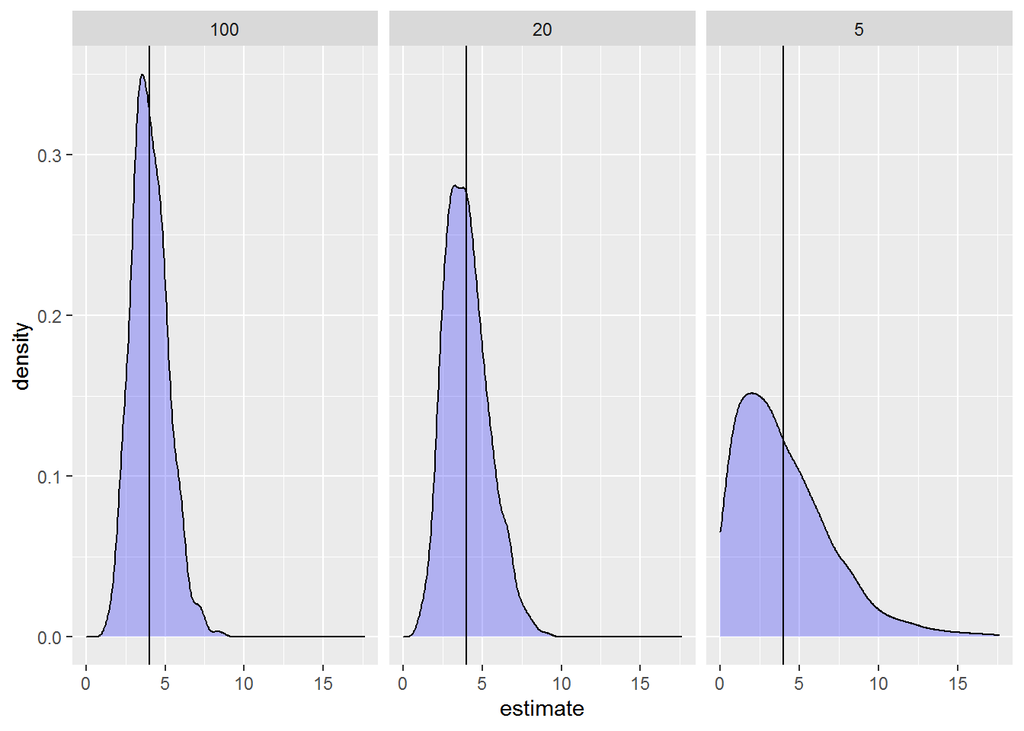

```r
ggplot(stand_vars, aes(x = estimate) ) +
     geom_density(fill = "blue", alpha = .25) +
     facet_wrap(~stand_num) +
     geom_vline(xintercept = 4)
```

Whoops, I need to get my factor levels in order.

```r
stand_vars = mutate(stand_vars, stand_num = forcats::fct_inorder(stand_num) )
```

I’ll also add some clearer labels for the facets.

```r
add_prefix = function(string) {
     paste("Number stands:", string, sep = " ")
}
```

And finally I’ll add the median of each distribution as a second vertical line.

```r
groupmed = stand_vars %>%
     group_by(stand_num) %>%
     summarise(mvar = median(estimate) )
```

Looking at the plots we can really see how poorly we can estimate variances when we have few replications. When only 5 stands are sampled, the variance can be estimated as low as 0 and as high as ~18 (😮) when it’s really 4.

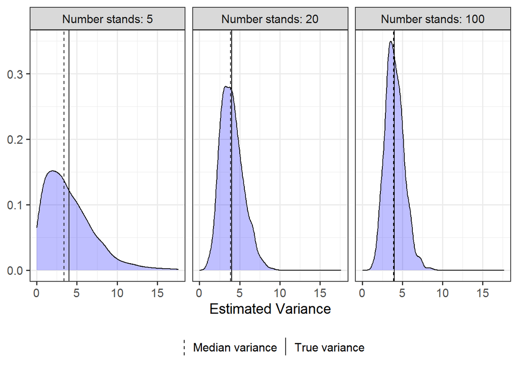

```r
ggplot(stand_vars, aes(x = estimate) ) +
     geom_density(fill = "blue", alpha = .25) +
     facet_wrap(~stand_num, labeller = as_labeller(add_prefix) ) +
     geom_vline(aes(xintercept = 4, linetype = "True variance"), size = .5 ) +
     geom_vline(data = groupmed, aes(xintercept = mvar, linetype = "Median variance"),
                size = .5) +
     theme_bw(base_size = 14) +
     scale_linetype_manual(name = "", values = c(2, 1) ) +
     theme(legend.position = "bottom",
           legend.key.width = unit(.1, "cm") ) +
     labs(x = "Estimated Variance", y = NULL)
```

Here are some additional descriptive statistics of the distribution of variances in each group to complement the info in the plot.

```r
stand_vars %>%
     group_by(stand_num) %>%
     summarise_at("estimate",
                  list(min = min, mean = mean, med = median, max = max) )
```

```bash
# # A tibble: 3 x 5
#   stand_num   min  mean   med   max
#   <fct>     <dbl> <dbl> <dbl> <dbl>
# 1 5         0      4.04  3.39 17.6
# 2 20        0.994  4.03  3.88  9.15
# 3 100       1.27   4.04  3.92  8.71
```

So how much of the distribution is below 4 for each estimate?

We can see for 5 samples that the variance is definitely underestimated more often than it is overestimated; almost 60% of the distribution is below the true variance of 4.

Every time I do this sort of simulation I am newly surprised that even large samples tend to underestimate variances slightly more often than overestimate them.

```r
stand_vars %>%
     group_by(stand_num) %>%
     summarise(mean(estimate < 4) )
```

```bash
# # A tibble: 3 x 2
#   stand_num `mean(estimate < 4)`
#   <fct>                    <dbl>
# 1 5                        0.577
# 2 20                       0.532
# 3 100                      0.525
```

My take home from all of this? We may need to be cautious with results for studies where the goal is to make inference about the estimates of the variances or for testing variables measured at the level of the largest unit when the number of units is small.

# An actual mixed model (with fixed effects this time)

I simplified things above so much that I didn’t have any fixed effects variables. We can certainly include fixed effects in a simulation.

Below is a quick example. I’ll create two continuous variables, one measured at the stand level and one measured at the plot level, that have linear relationships with the mean response variable. The study is the same as the one I defined for the previous simulation.

Here’s the new statistical model.

Where

- $β0β0$ is the mean response when both Elevation and Slope are 0
- $β1β1$ is the change in mean response for a 1-unit change in elevation. Elevation is measured at the stand level, so all plots in a stand share a single value of elevation.
- $β2β2$ is the change in mean response for a 1-unit change in slope. Slope is measured at the plot level, so every plot potentially has a unique value of slope.

Setting the values for the three new parameters and simulating values for the continuous explanatory variables will be additional steps in the simulation. The random effects are simulated the same way as before.

I define the new parameters below.

- The intercept ($β0β0$) will be -1
- The coefficient for elevation ($β1β1$) will be set to 0.005
- The coefficient for slope ($β2β2$) will be set to 0.1

```r
nstand = 5
nplot = 4
b0 = -1
b1 = .005
b2 = .1
sds = 2
sd = 1
```

Here are the variables I simulated previously.

```r
set.seed(16)
stand = rep(LETTERS[1:nstand], each = nplot)
standeff = rep( rnorm(nstand, 0, sds), each = nplot)
ploteff = rnorm(nstand*nplot, 0, sd)
```

I will simulate the explanatory variables by randomly drawing from uniform distributions via `runif()`. I change the minimum and maximum values of the uniform distribution as needed to get an appropriate spread for a given variable. If the distribution of your explanatory variables are more skewed you could use a different distribution (like the Gamma distribution).

First I simulate values for elevation. This variable only five values, as it is a stand-level variable. I need to repeat each value for the four plots measured in each stand like I did when making the `stand` variable.

```r
( elevation = rep( runif(nstand, 1000, 1500), each = nplot) )
```

```css
#  [1] 1468.339 1468.339 1468.339 1468.339 1271.581 1271.581 1271.581 1271.581
#  [9] 1427.050 1427.050 1427.050 1427.050 1166.014 1166.014 1166.014 1166.014
# [17] 1424.256 1424.256 1424.256 1424.256
```

I can simulate slope the same way, pulling random values from a uniform distribution with different limits. The slope is measured at the plot level, so I have one value for every plot in the dataset.

```r
( slope = runif(nstand*nplot, 2, 75) )
```

```css
#  [1] 48.45477 60.37014 59.58588 44.76939 61.88313 20.29559 71.51617 42.35035
#  [9] 63.67044 36.43613 10.58778 14.62304 35.11192 13.19697  9.29946 46.56462
# [17] 34.68245 53.61456 37.00606 42.30044
```

We now have everything we need to create the response variable.

the response variable will be calculated via

```r
( resp2 = b0 + b1*elevation + b2*slope + standeff + ploteff )
```

```css
#  [1] 11.671585 12.325584 13.316671 12.796432 11.868602  8.983889 12.370697
#  [8]  8.596145 16.352939 12.693014  7.723378 10.365894  5.925563  2.718576
# [15]  3.999244  4.950275 11.571009 13.595712 13.588022 11.781083
```

Now we can fit a mixed model for `resp2` with `elevation` and `slope` as fixed effects, `stand` as the random effect and the residual error term based on plot-to-plot variation. (*Notice I didn’t put these variables in a dataset, which I usually like to do to keep things organized and to avoid problems of vectors in my environment getting overwritten by mistake.*)

We can see some of the estimates in this one model aren’t very similar to our set values, and doing a full simulation would allow us to explore the variation in the estimates. For example, I expect the coefficient for elevation, based on only five values, will be extremely unstable.

```r
lmer(resp2 ~ elevation + slope + (1|stand) )
```

```bash
# Linear mixed model fit by REML ['lmerMod']
# Formula: resp2 ~ elevation + slope + (1 | stand)
# REML criterion at convergence: 81.9874
# Random effects:
#  Groups   Name        Std.Dev.
#  stand    (Intercept) 1.099
#  Residual             1.165
# Number of obs: 20, groups:  stand, 5
# Fixed Effects:
# (Intercept)    elevation        slope
#   -21.31463      0.02060      0.09511
```

# Just the code, please

Here’s the code without all the discussion. Copy and paste the code below or you can download an R script of uncommented code [from here](https://aosmith.rbind.io/script/2018-04-23-simulate-simulate-part-2-a-linear-mixed-model.R).

```r
set.seed(16)
nstand = 5
nplot = 4
mu = 10
sds = 2
sd = 1

( stand = rep(LETTERS[1:nstand], each = nplot) )
( plot = letters[1:(nstand*nplot)] )
( standeff = rnorm(nstand, 0, sds) )
( standeff = rep(standeff, each = nplot) )
( ploteff = rnorm(nstand*nplot, 0, sd) )

( dat = data.frame(stand, standeff, plot, ploteff) )

( dat$resp = with(dat, mu + standeff + ploteff ) )

library(lme4) # v. 1.1-21

fit1 = lmer(resp ~ 1 + (1|stand), data = dat)
fit1

twolevel_fun = function(nstand = 5, nplot = 4, mu = 10, sigma_s = 2, sigma = 1) {
     standeff = rep( rnorm(nstand, 0, sigma_s), each = nplot)
     stand = rep(LETTERS[1:nstand], each = nplot)
     ploteff = rnorm(nstand*nplot, 0, sigma)
     resp = mu + standeff + ploteff
     dat = data.frame(stand, resp)
     lmer(resp ~ 1 + (1|stand), data = dat)
}

set.seed(16)
twolevel_fun()

sims = replicate(100, twolevel_fun(), simplify = FALSE )
sims[[100]]

library(broom) # v. 0.5.6
tidy(fit1)

tidy(fit1, effects = "fixed")

tidy(fit1, effects = "ran_pars", scales = "vcov")

library(purrr) # v. 0.3.3
suppressPackageStartupMessages( library(dplyr) ) # v. 0.8.3
library(ggplot2) # v. 3.2.1

stand_sims = c(5, 20, 100) %>%
     set_names() %>%
     map(~replicate(1000, twolevel_fun(nstand = .x) ) )

stand_vars = stand_sims %>%
     modify_depth(2, ~tidy(.x, effects = "ran_pars", scales = "vcov") ) %>%
     map_dfr(bind_rows, .id = "stand_num") %>%
     filter(group == "stand")
head(stand_vars)

ggplot(stand_vars, aes(x = estimate) ) +
     geom_density(fill = "blue", alpha = .25) +
     facet_wrap(~stand_num) +
     geom_vline(xintercept = 4)

stand_vars = mutate(stand_vars, stand_num = forcats::fct_inorder(stand_num) )

add_prefix = function(string) {
     paste("Number stands:", string, sep = " ")
}

groupmed = stand_vars %>%
     group_by(stand_num) %>%
     summarise(mvar = median(estimate) )

ggplot(stand_vars, aes(x = estimate) ) +
     geom_density(fill = "blue", alpha = .25) +
     facet_wrap(~stand_num, labeller = as_labeller(add_prefix) ) +
     geom_vline(aes(xintercept = 4, linetype = "True variance"), size = .5 ) +
     geom_vline(data = groupmed, aes(xintercept = mvar, linetype = "Median variance"),
                size = .5) +
     theme_bw(base_size = 14) +
     scale_linetype_manual(name = "", values = c(2, 1) ) +
     theme(legend.position = "bottom",
           legend.key.width = unit(.1, "cm") ) +
     labs(x = "Estimated Variance", y = NULL)

stand_vars %>%
     group_by(stand_num) %>%
     summarise_at("estimate",
                  list(min = min, mean = mean, med = median, max = max) )

stand_vars %>%
     group_by(stand_num) %>%
     summarise(mean(estimate < 4) )

nstand = 5
nplot = 4
b0 = -1
b1 = .005
b2 = .1
sds = 2
sd = 1

set.seed(16)
stand = rep(LETTERS[1:nstand], each = nplot)
standeff = rep( rnorm(nstand, 0, sds), each = nplot)
ploteff = rnorm(nstand*nplot, 0, sd)

( elevation = rep( runif(nstand, 1000, 1500), each = nplot) )
( slope = runif(nstand*nplot, 2, 75) )
( resp2 = b0 + b1*elevation + b2*slope + standeff + ploteff )

lmer(resp2 ~ elevation + slope + (1|stand) )
```

[simulation](https://aosmith.rbind.io/tags/simulation/) [lmm](https://aosmith.rbind.io/tags/lmm/) [lme4](https://aosmith.rbind.io/tags/lme4/)